# Assignment_2_2913_jander98

## Part II: Simulation Study

Consider the following **five** procedures:

- **Full**: Fit a linear regression model using all features
- **Ridge.min**: Ridge regression using lambda.min
- **Lasso.min** and **Lasso.1se**: Lasso using lambda.min or lambda.1se
- **L.Refit**: Refit the model selected by Lasso using lambda.1se
- **PCR**: principle components regression with the number of components chosen by 10-fold cross validation

### Case I

Download the data set Coding2_Data1.csv. The first 14 columns are the same as the data set we used in Part I with Y being the response variable (moved to the 1st column). The additional 78 more predictors are the quadratic and pairwise product terms of the original 13 predictors.

- [a] Conduct the following simulation exercise **50** times:

  – In each iteration, randomly split the data into two parts, **75%** for training and **25%** for testing.

  – For each of the **five** procedures, train a model using the training subset and generate predictions for the test subset. Record the **MSPE** (Mean Squared Prediction Error) based on these test data predictions.
- [b] Graphically summarize your findings on the MSPE using a strip chart, and consider overlaying a boxplot for additional insights.

```r
library(doParallel)#general parallel backend support
library(foreach)#Looping in paralel
library(doRNG)

run_simulation = function(data, T = 50, methods = c("Full", "Ridge.min", "Lasso.min", "Lasso.1se", "L.Refit", "PCR"), PARALLEL = FALSE) {

  # Check for valid method names, stop if wrong names
  valid_methods = c("Full", "Ridge.min", "Lasso.min", "Lasso.1se", "L.Refit", "PCR")
  if (!all(methods %in% valid_methods)) {
    stop("Invalid method(s) specified in 'methods' parameter.")
  }
  #If we are parallelizing we load necessary libraries
  if (PARALLEL) {
    library(doParallel)#general parallel backend support
    library(foreach)#Looping in paralel
    library(doRNG)#reproducibility in parallel
  }
  # Prepare data
  X = data.matrix(data[,-1])
  Y = data[,1]
  n = length(Y)
  ntest = round(n * 0.25)#Test set size [25% of data]
  ntrain = n - ntest#Training set size [remaining 75%]
  number_observations = n

  # Generate indices for test sets
  all.test.id = replicate(T, sample(1:n, ntest))

  # Initialize vectors to store MSPEs for selected methods
  MSPEs = list()
  selected_features_list = list()

  for (method in methods) {
    MSPEs[[method]] = numeric(T)
    selected_features_list[[method]] = numeric(T)
  }

  #Define lambda sequence for Ridge
  mylasso.lambda.seq = exp(seq(-10, 1, length.out = 100))

  # Set up parallel backend if PARALLEL is TRUE
  if (PARALLEL) {
    numCores = parallel::detectCores() - 1# Leave one core free, detect cores
    cl = makeCluster(numCores)#parallel cluster init
    registerDoParallel(cl)#register parallel backend
    clusterEvalQ(cl, {
      library(glmnet)
      library(pls)
      library(doRNG)  # Ensure all workers load required libraries
    })
    `%dopar%` = `%dorng%`  # Use doRNG for reproducible parallel loops
  } else {
    `%dopar%` = foreach::`%do%`#else sequential exec
  }

  # Now run the simulations, will do in paralle or sequential depending on arg
  results = foreach(t = 1:T, .packages = c('glmnet', 'pls')) %dopar% {
    # Initialize a list to store results for this iteration
    res = list()
    selected_features = list()

    # Split data into training and testing sets
    test.id = all.test.id[, t]
    train.id = setdiff(1:n, test.id)

    # Full model (Ordinary Least Squares)
    if ("Full" %in% methods) {
      full.model = lm(Y ~ ., data = data[train.id, ])
      Ytest.pred = predict(full.model, newdata = data[test.id, ])
      res$Full = mean((data$Y[test.id] - Ytest.pred)^2)
    }

    # Ridge regression using lambda.min
    if ("Ridge.min" %in% methods) {
      #Cross validation for Ridge
      cv.out = cv.glmnet(X[train.id, ], Y[train.id], alpha = 0, lambda = mylasso.lambda.seq)
      #Get best lambda(lambda.min)
      best.lam = cv.out$lambda.min
      #Predict on test set
      Ytest.pred = predict(cv.out, s = best.lam, newx = X[test.id, ])
      #Calc MSPE for ridge regression
      res$Ridge.min = mean((Y[test.id] - Ytest.pred)^2)

      best_lambda_coefs_ridge = coef(cv.out, s = best.lam)
      selected_features$Ridge.min = sum(best_lambda_coefs_ridge != 0) - 1
    }

    # Lasso regression
    if (any(c("Lasso.min", "Lasso.1se", "L.Refit") %in% methods)) {
      #Perform cross validation for lasso
      cv.out = cv.glmnet(X[train.id, ], Y[train.id], alpha = 1)
    }

    if ("Lasso.min" %in% methods) {
      best.lam = cv.out$lambda.min
      #predict on test set
      Ytest.pred = predict(cv.out, s = best.lam, newx = X[test.id, ])
      #calc MSPE for lasso
      res$Lasso.min = mean((Y[test.id] - Ytest.pred)^2)

      best_lambda_coefs_lasso = coef(cv.out, s = best.lam)
      selected_features$Lasso.min = sum(best_lambda_coefs_lasso != 0) - 1
    }

    # Lasso.1se [less agressive regularization]
    if ("Lasso.1se" %in% methods) {
      best.lam = cv.out$lambda.1se
      Ytest.pred = predict(cv.out, s = best.lam, newx = X[test.id, ])
      res$Lasso.1se = mean((Y[test.id] - Ytest.pred)^2)

      best_lambda_coefs_lasso_1se = coef(cv.out, s = best.lam)
      selected_features$Lasso.1se = sum(best_lambda_coefs_lasso_1se != 0) - 1
    }

    # Lasso refit
    if ("L.Refit" %in% methods) {
      best.lam = cv.out$lambda.1se
      mylasso.coef = predict(cv.out, s = best.lam, type = "coefficients")
      var.sel = row.names(mylasso.coef)[which(mylasso.coef != 0)[-1]]
      if (length(var.sel) > 0) {
        mylasso.refit = lm(Y ~ ., data[train.id, c("Y", var.sel)])
        Ytest.pred = predict(mylasso.refit, newdata = data[test.id, ])
        res$L.Refit = mean((Ytest.pred - Y[test.id])^2)
        selected_features$L.Refit = length(var.sel)
      } else {
        # If no variables selected, predict using mean of training Y
        Ytest.pred = mean(Y[train.id])
        res$L.Refit = mean((Y[test.id] - Ytest.pred)^2)
        selected_features$L.Refit = 0
      }
    }

    # PCR
    if ("PCR" %in% methods) {
      mypcr = pcr(Y ~ ., data = data[train.id, ], validation = "CV", scale = TRUE)
      CVerr = RMSEP(mypcr)$val[1, , ]
      best.ncomp = which.min(CVerr) - 1# Adjust index
      if (best.ncomp == 0) { #handle one off case
        Ytest.pred = mean(Y[train.id])
      } else {
        Ytest.pred = predict(mypcr, data[test.id, ], ncomp = best.ncomp)
      }
      res$PCR = mean((Ytest.pred - Y[test.id])^2)

      pcr_coefficients = coef(mypcr)
      selected_features$PCR = sum(pcr_coefficients != 0) - 1
    }

    return(list(mspe = res, selected_features = selected_features))
  }

  # Stop the parallel backend if used
  if (PARALLEL) {
    stopCluster(cl)
  }

  # Collect results
  for (t in 1:T) {
    res = results[[t]]$mspe
    selected_features_res = results[[t]]$selected_features
    for (method in names(res)) {
      MSPEs[[method]][t] = res[[method]]

      # Handle cases where no features were selected
      if (!is.null(selected_features_res[[method]]) && length(selected_features_res[[method]]) > 0) {
        selected_features_list[[method]][t] = selected_features_res[[method]]
      } else {
        selected_features_list[[method]][t] = 0  # Default to 0 if no features are selected
      }
    }
  }

  return(list(MSPEs = MSPEs, selected_features_list = selected_features_list))
}
```

- [b] Graphically summarize your findings on the MSPE using a strip chart, and consider overlaying a boxplot for additional insights.

```r
# Load necessary libraries
library(pls) # For Principal Component Regression(PCR)
myData = read.csv("Coding2_Data1.csv", header = TRUE)

# Example default run, parallel true
simulation_result = run_simulation(data = myData, T = 50, PARALLEL = TRUE)
MSPEs = simulation_result$MSPEs
selected_features_list = simulation_result$selected_features_list
# Remove "Full" from the selected_features_list because it doesn't involve feature selection
selected_features_list_filtered = selected_features_list[names(selected_features_list) != "Full"]

number_of_observations = nrow(myData)

# Summarize MSPEs for all methods
summary_df = data.frame(
  Method = names(MSPEs),
  Mean_MSPE = sapply(MSPEs, mean),
  SD_MSPE = sapply(MSPEs, sd)
)

# Plot MSPEs
library(reshape2)
library(ggplot2)
library(knitr)

# Combine MSPEs into a data frame for plotting
MSPEs_melted = melt(MSPEs)

# Rename columns to 'Method' and 'MSPE'
colnames(MSPEs_melted) = c("Method", "MSPE")

kable(summary_df,
      col.names = c("Method", "Mean MSPE", "Standard Deviation of MSPE"),
      align = "c",
      caption = "Case 1: MSPEs of Different Procedures over 50 Simulations",
      row.names = FALSE)
```

Case 1: MSPEs of Different Procedures over 50 Simulations

| Method | Mean MSPE | Standard Deviation of MSPE |
| --- | --- | --- |
| Full | 0.0291472 | 0.0068375 |
| Ridge.min | 0.0260959 | 0.0039821 |
| Lasso.min | 0.0265810 | 0.0043311 |
| Lasso.1se | 0.0299668 | 0.0046651 |
| L.Refit | 0.0296519 | 0.0049195 |
| PCR | 0.0287917 | 0.0062586 |

```r
# Summarize selected features and difference (exclude Full from selection list)
num_selected_features_df = data.frame(
  Method = c("Ridge.min", "Lasso.min", "Lasso.1se", "L.Refit", "PCR"),
  Number_of_Observations = rep(number_of_observations, 5),  # Same for all methods
  Mean_Selected_Features = round(sapply(selected_features_list_filtered, mean)),
  Mean_Difference = round(sapply(selected_features_list_filtered, function(x) mean(nrow(myData) - x)))
)

kable(num_selected_features_df,
      col.names = c("Method", "Number of Observations", "Number of Selected Features(Mean)", "Observations vs. Features (n - p)"),
      align = "c",
      caption = "Method Comparison: Observations, Mean Selected Features, and n-p in Case 1",
      row.names = FALSE)
```

Method Comparison: Observations, Mean Selected Features, and n-p in Case 1

| Method | Number of Observations | Number of Selected Features(Mean) | Observations vs. Features (n - p) |
| --- | --- | --- | --- |
| Ridge.min | 506 | 91 | 415 |
| Lasso.min | 506 | 61 | 445 |
| Lasso.1se | 506 | 33 | 473 |
| L.Refit | 506 | 33 | 473 |
| PCR | 506 | 90 | 416 |

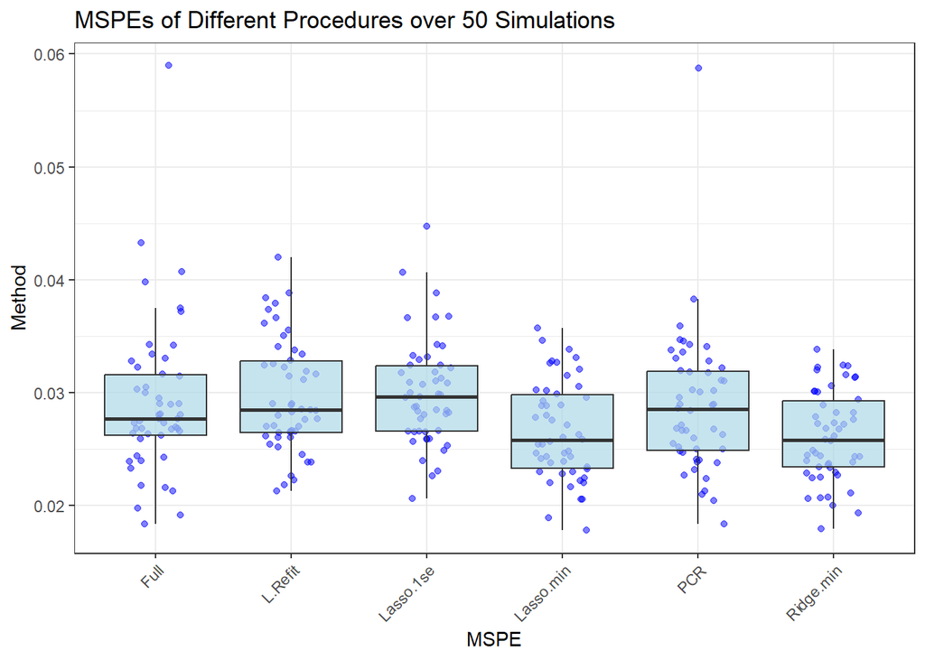

```r
# Plot MSPEs
plot1 = ggplot(MSPEs_melted, aes(x = MSPE, y = Method)) +
  geom_jitter(width = 0.2, alpha = 0.5, color = "blue") +
  geom_boxplot(alpha = 0.7, outlier.shape = NA, fill = "lightblue") +
  theme_bw() +
  labs(title = "MSPEs of Different Procedures over 50 Simulations",
       x = "MSPE",
       y = "Method") +
  theme(axis.text.x = element_text(angle = 45, hjust = 1))

print(plot1)
```

- [c] Based on the outcomes of your simulation study, please address the following questions:

– Which procedure or procedures yield the best performance in terms of MSPE? – Conversely, which procedure or procedures show the poorest performance?

**Answer**: Based on the boxplot chart ( with 75% for training and 25% for testing ) , Lasso Min and Ridge Min models have the lowest MSPE and the most consistent performance among all models.Based on the boxplot chart ( with 75% for training and 25% for testing ), the Lasso.1se model shows the poorest performance.

– In the context of Lasso regression, which procedure, **Lasso.min** or **Lasso.1se**, yields a better MSPE?

**Answer**: Based on the Case I simulation study MSPE results, Lasso.min has the better MSPE.

– Is refitting advantageous in this case? In other words, does **L.Refit** outperform **Lasso.1se**?

**Answer**: Based on the Case I simulation study MSPE results, L.Refit shows a slight improvement over Lasso.1se in terms of Mean MSPE; however, when considering the Standard Deviation of MSPE, Lasso.1se exhibits a lower variability than L.Refit. This comparison, highlighted in the “Case 1 MSPEs of Different Procedures over 50 Simulations” table, suggests that while the refitting process offers some advantage in mean performance, it comes with increased variability. Therefore, while L.Refit can be seen as a marginally better option in terms of average performance, the lower standard deviation of Lasso.1se indicates that it may be a more reliable choice overall.

– Is variable selection or shrinkage warranted for this particular dataset? To clarify, do you find the performance of the **Full** model to be comparable to, or divergent from, the best-performing procedure among the other five?

**Answer**: Based on the analysis of the dataset, variable selection or shrinkage is not warranted for this particular dataset. The Full model performs comparably to the best-performing Ridge.min model and Lasso.min model, which utilized all 91 and 61 features, respectively, as indicated in the “Method Comparison: Observations, Mean Selected Features, and n-p in Case 1” table.

Ridge regression outperformed the Full model in terms of MSPE, demonstrating that retaining all features can still yield strong performance. In contrast, models like Lasso.1se and Lasso.Refit, which selected fewer features, did not achieve the same level of performance as the Full model.

This suggests that, while Ridge effectively manages complexity through shrinkage, the Full model’s performance indicates that variable selection is not necessary in this case. Retaining all features allows the Full model to leverage all available information, resulting in competitive predictive accuracy.

### Case II

Download the data set Coding2_Data2.csv. The first 92 columns are identical to those in Coding2_Data1.csv, with the addition of 500 columns of artificially generated **noise features**.

```r
data2 = read.csv("Coding2_Data2.csv", header = TRUE)
simulation_result = run_simulation(data = data2, methods =c( "Ridge.min", "Lasso.min", "Lasso.1se", "L.Refit", "PCR"),  T = 50, PARALLEL = TRUE)
MSPEs = simulation_result$MSPEs
selected_features_list = simulation_result$selected_features_list
# Remove "Full" from the selected_features_list because it doesn't involve feature selection
selected_features_list_filtered = selected_features_list[names(selected_features_list) != "Full"]
number_of_observations = nrow(myData)
```

- Repeat [a] and [b] above for the **five** procedures **excluding** the **Full** procedure. Graphically summarize your findings on MSPE using a strip chart, and consider overlaying a boxplot for additional insights.

```r
# Summarize MSPEs for all methods
summary_df = data.frame(
  Method = names(MSPEs),
  Mean_MSPE = sapply(MSPEs, mean),
  SD_MSPE = sapply(MSPEs, sd)
)

# Plot MSPEs
library(reshape2)
library(ggplot2)
library(knitr)

# Combine MSPEs into a data frame for plotting
MSPEs_melted = melt(MSPEs)

# Rename columns to 'Method' and 'MSPE'
colnames(MSPEs_melted) = c("Method", "MSPE")

kable(summary_df,
      col.names = c("Method", "Mean MSPE", "Standard Deviation of MSPE"),
      align = "c",
      caption = "Case 2: MSPEs of Different Procedures over 50 Simulations",
      row.names = FALSE)
```

Case 2: MSPEs of Different Procedures over 50 Simulations

| Method | Mean MSPE | Standard Deviation of MSPE |
| --- | --- | --- |
| Ridge.min | 0.0525890 | 0.0079196 |
| Lasso.min | 0.0415062 | 0.0074932 |
| Lasso.1se | 0.0454104 | 0.0079256 |
| L.Refit | 0.0431280 | 0.0078293 |
| PCR | 0.0552612 | 0.0078016 |

```r
# Summarize selected features and difference (exclude Full from selection list)
num_selected_features_df = data.frame(
  Method = c("Ridge.min", "Lasso.min", "Lasso.1se", "L.Refit", "PCR"),
  Number_of_Observations = rep(number_of_observations, 5),  # Same for all methods
  Mean_Selected_Features = round(sapply(selected_features_list_filtered, mean)),
  Mean_Difference = round(sapply(selected_features_list_filtered, function(x) mean(nrow(myData) - x)))
)

kable(num_selected_features_df,
      col.names = c("Method", "Number of Observations", "Number of Selected Features(Mean)", "Observations vs. Features (n - p)"),
      align = "c",
      caption = "Method Comparison: Observations, Mean Selected Features, and n-p in Case 2",
      row.names = FALSE)
```

Method Comparison: Observations, Mean Selected Features, and n-p in Case 2

| Method | Number of Observations | Number of Selected Features(Mean) | Observations vs. Features (n - p) |
| --- | --- | --- | --- |
| Ridge.min | 506 | 591 | -85 |
| Lasso.min | 506 | 38 | 468 |
| Lasso.1se | 506 | 7 | 499 |
| L.Refit | 506 | 7 | 499 |
| PCR | 506 | 590 | -84 |

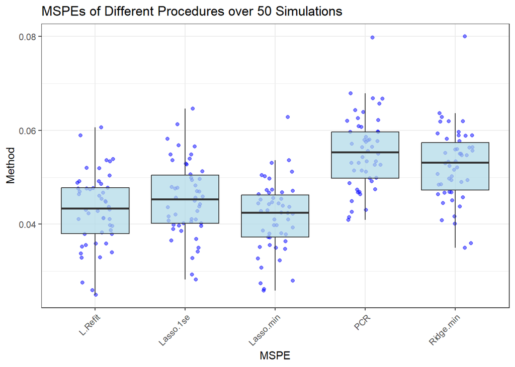

```r
# Plot MSPEs
plot2 = ggplot(MSPEs_melted, aes(x = MSPE, y = Method)) +
  geom_jitter(width = 0.2, alpha = 0.5, color = "blue") +
  geom_boxplot(alpha = 0.7, outlier.shape = NA, fill = "lightblue") +
  theme_bw() +
  labs(title = "MSPEs of Different Procedures over 50 Simulations",
       x = "MSPE",
       y = "Method") +
  theme(axis.text.x = element_text(angle = 45, hjust = 1))

print(plot2)
```

- [c] Address the following questions:

– Which procedure or procedures yield the best performance in terms of MSPE? – Conversely, which procedure or procedures show the poorest performance?

**Answer**: In Case II, Lasso.min yields the best performance, with the lowest MSPE. Conversely, PCR shows the poorest performance, with the highest MSPE.

– Have you observed any procedure or procedures that performed well in Case I but exhibited poorer performance in Case II, or vice versa? If so, please offer an explanation.

**Answer**: Yes, we observed that in Case I, the Ridge.min model had the lowest MSPE, while in Case II, the Lasso.min model performed best. This does not align with the expectation that the best MSPE in Case II would be equal to or lower than in Case I, given that Coding2_Data2.csv includes all features from Coding2_Data1.csv, with an additional 500 features of noise.

In Case II, the Ridge.min model retained all 591 features, as ridge regression does not eliminate features but only shrinks their coefficients. This means all features, including noise, still influence the model’s predictions. In contrast, Case I had only 91 features, leading to lower variance for the least squares estimates, which is why Ridge.min performed better there.

The “Method Comparison: Observations, Mean Selected Features, and n-p in Case 2” table further illustrates this point by showing the mean number of selected features for each method. For instance, Lasso.min effectively reduced the mean number of selected features, indicating its ability to manage complexity more efficiently.

Therefore, the poorer performance of Ridge.min in Case II can be attributed to the increased noise and complexity, while Lasso.min effectively managed the situation by selecting relevant features.

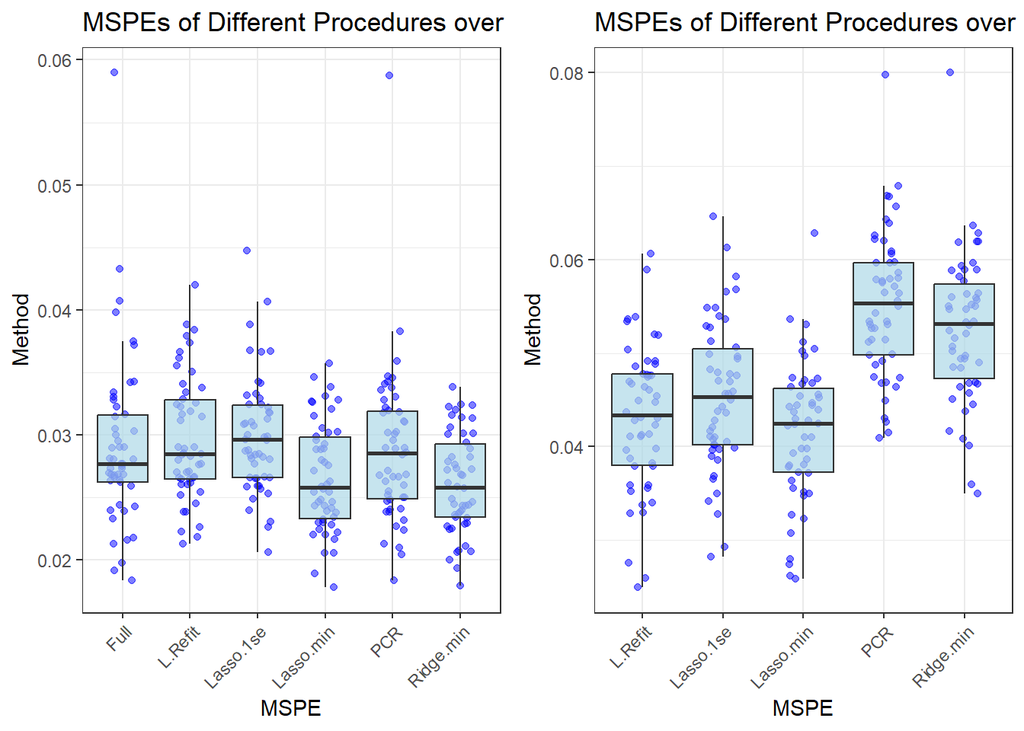

```r
library(gridExtra)
grid.arrange(plot1, plot2, ncol = 2)
```

– Given that Coding2_Data2.csv includes all features found in Coding2_Data1.csv, one might anticipate that the best MSPE in Case II would be equal to or lower than the best MSPE in Case I. Do your simulation results corroborate this expectation? If not, please offer an explanation.

**Answer**: In Case II, the Lasso.min model has the lowest MSPE, whereas in Case I, the Ridge.min model performs best. The primary difference between the cases is the number of features: Case II has 591 features, while Case I has only 91.

However, the underlying differences between how Ridge and Lasso operate explain this performance discrepancy. Ridge regression shrinks the coefficients of all features but does not eliminate any, meaning that even irrelevant features can influence the model’s predictions. In Case II, this includes a significant amount of noise, which can lead to overfitting and poorer performance.

On the other hand, Lasso regression not only shrinks coefficients but also has the ability to set some coefficients to zero, effectively performing feature selection. This characteristic allows Lasso.min to disregard less relevant or noisy features in Case II, leading to a more robust model that generalizes better to unseen data. The “Method Comparison: Observations, Mean Selected Features, and n-p in Case 2” table further illustrates this by showing the mean number of selected features for each method, highlighting how Lasso.min managed to reduce complexity effectively.

Thus, the results corroborate the expectation that simply having more features does not guarantee better performance, especially when noise is present. The effectiveness of Lasso in Case II highlights the importance of feature selection in improving model performance.